# Homework 2

**Due:** Friday, September 15, 11:00am on Canvas

**Instructions:**

- Download the [HW 2 template](https://sta279-f23.github.io/homework/hw_2_template.qmd), and open the template (a Quarto document) in RStudio.
- Put your name in the file header
- Click `Render`
- Type all code and answers in the document (using `###` for section headings and `####` for question headings)
- Render early and often to catch any errors!
- When you are finished, submit the final rendered HTML to Canvas

**Code guidelines:**

- If a question requires code, and code is not provided, you will not receive full credit
- You will be graded on the quality of your code. In addition to being correct, your code should also be easy to read
  - No magic numbers
  - Use descriptive names for your variables
  - Set seeds where needed
  - Comment code
  - If a block of code is being called multiple times, put it in a function

**Resources:** Homework 2 will give you practice with loops, `if` statements, simulation, and functions. In addition to the class notes and activities, I recommend reading the following resources:

- [Chapter 3.1 – 3.2](https://adv-r.hadley.nz/vectors-chap.html) (an introduction to vectors) in *Advanced R*
- [Chapter 5](https://adv-r.hadley.nz/control-flow.html) (loops and choices) in *Advanced R*
- [Appendix C.2](https://mdsr-book.github.io/mdsr3e/C-algorithmic.html#simple-example) in *Modern Data Science with R*
- [Chapter 19.1 – 19.5.2](https://r4ds.had.co.nz/functions.html) (functions and conditions) in *R for Data Science* (1st edition)

### Probability simulation

Suppose there are exactly 100 seats in a movie theater. Further, suppose the movie theater has imposed a new ticketing system where each person’s has an assigned seat number. Consider the case where the movie is sold-out (all 100 seats will be taken) and the first person in the theater lost their ticket and takes a random seat. Each subsequent person attempts to go to their seat. If their seat is open, they take it. Otherwise, to avoid confrontation, they choose a random seat.

#### Question 1

Conduct a simulation to assess the probability that the last person into the theater will get their assigned seat.

*Tips:* Here are some tips for one approach to this simulation.

- Create a vector `seats`, containing the numbers 1,…,100 in order, to represent the (numbered) seats in the theater
- Create a vector, `taken`, to represent which seats have been taken. At the beginning of each run of the simulation, all entries of `taken` are 0.
- When a seat gets taken, change the corresponding entry in `taken` to 1
- Use `sample` to randomly choose a seat from the ones available
- `seats[taken == 0]` will tell you which seats are available

### Probability simulation

Consider the following $(a + 1)$ player game (Gal and Miltersen, 2007). There are $a$ boxes with labels $1, ..., a$ and slips of paper labeled $1, 2, ..., a$ The lead player colors each slip of paper either red or blue and puts each slip of paper in a box so there is one and only one slip of paper per box, without the other $a$ players observing.

Now, each player $i ∈ {1, 2, ..., a}$ can look in at most $a/2$ boxes and based on this make a guess about the color of the slip $i$. This done by each player in isolation. The $a$ players win if *every* player correctly announces the color of “their” slip.

#### Question 2

Conduct a simulation where the lead player colors the slips and adds them to the boxes at random. The other players randomly choose which boxes to open. What proportion of the time do all of the players see their own slip, guaranteeing they win? Does the proportion depend on $a$?

*Tip:* To efficiently check whether a vector contains a specific value, you can use `%in%`. For example,

```r
3 %in% c(1, 2, 3)
```

```
## [1] TRUE
```

```r
4 %in% c(1, 2, 3)
```

```
## [1] FALSE
```

#### Question 3

Conduct a simulation where the lead player colors the slips and adds them to the boxes at random. The other players randomly choose which boxes to open. Suppose a player that doesn’t see their own slip randomly guesses either red or blue. What proportion of the time do the $a$ players win?

### Practice with functions

The Huber loss function is defined as

$$\psi(x) = \begin{cases} x^2 &
\text{if } |x| \leq 1 \\ 2|x| - 1 & \text{if } |x| >
1 \end{cases}$$

This function is quadratic on the interval $[-1,1]$, and linear outside of this interval. It transitions from quadratic to linear “smoothly”, and it is often used in place of the usual squared error loss for robust estimation.

#### Question 4

Write a function `huber()` that takes as an input a number $x$, and returns the Huber value $\psi(x)$. Here is a code skeleton to get you started:

```r
huber <- function(x){

}
```

*Hint:* The `ifelse` function from class will be helpful!

#### Question 5

HW 1 introduced the idea of *vectorization*. The `ifelse` function is vectorized, so if you used the `ifelse` function in Question 4, your `huber` function should also be vectorized.

Check that the function is vectorized: e.g., `huber(c(0.5, 1, 2))` should return `0.25 1.00 3.00`

The Huber function can be modified so that the transition from quadratic to linear happens at an arbitrary cutoff value $a$, as in:

$$\psi_a(x) = \begin{cases} x^2 &
\text{if } |x| \leq a \\ 2|x| - 1 & \text{if } |x| >
a \end{cases}$$

#### Question 6

Starting with your solution code to Question 4, update your `huber()` function so that it takes two arguments: $x$, a number at which to evaluate the loss, and $a$ a number representing the cutoff value. It should now return $\psi_a(x)$, as defined above. Make $a = 1$ the *default* in your `huber` function.

### Logistic regression diagnostics

As you learned in STA 112, *linear* regression is used with quantitative responses, whereas *logistic* regression is used for binary responses ($Y_i = 0$ or $1$). In particular, if $\pi_i = P(Y_i = 1)$, then a simple logistic regression model (with explanatory variable $X_i$) is
$$\log
\left( \frac{\pi_i}{1 - \pi_i} \right) = \beta_0 + \beta_1
X_i$$

As an example, consider a dataset of 3402 pitches thrown by MLB pitcher Clayton Kershaw in the 2013 season. The data is contained in the `Kershaw` data set, in the `Stat2Data` R package. We will focus on two specific variables for each pitch:

- `Result`: a negative result (a ball or a hit), or a positive result (a strike or an out)
- `EndSpeed`: the speed at which the ball crossed home plate (in mph)

Our goal is to investigate the relationship between pitch speed and result. We can fit a logistic regression model, with `EndSpeed` as the explanatory variable and `Result` as the response:

```r
library(tidyverse)
library(Stat2Data)
data("Kershaw")

log_reg <- glm(Result ~ EndSpeed, family = binomial, data = Kershaw)
summary(log_reg)
```

[output not shown]

So far, so good! But, how do we assess the assumptions for this logistic regression model? The usual residual plots (like we would make for linear regression) are not helpful:

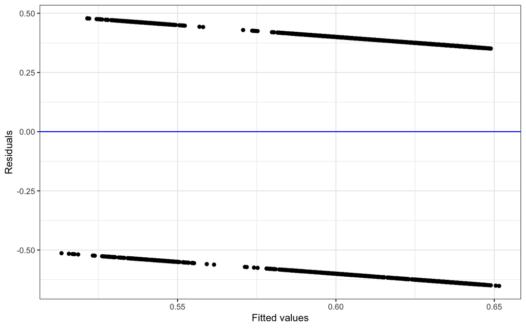

```r
data.frame(fitted = log_reg$fitted.values,
           residuals = log_reg$y - log_reg$fitted.values) |>
  ggplot(aes(x = fitted, y = residuals)) +
  geom_abline(slope = 0, intercept = 0, color = "blue") +
  geom_point() +
  labs(x = "Fitted values", y = "Residuals") +
  theme_bw()
```

Instead of the raw residuals $Y_i - \widehat{\pi}_i$, it is common in logistic regression to use a type of residual called *randomized quantile residuals*. For logistic regression, a randomized quantile residual is defined as follows:

$$r_{Q}(Y_i, \widehat{\pi}_i) =
\Phi^{-1}(u) \hspace{1cm} u \sim \begin{cases}
Uniform(1 - \widehat{\pi}_i, 1) & Y_i = 1 \\
Uniform(0, 1 - \widehat{\pi}_i) & Y_i = 0,
\end{cases}$$

In other words:

- If $Y_i = 1$, draw a random number $u$ from a $Uniform(1 - \widehat{\pi}_i, 1)$ distribution
  - Else ($Y_i = 0$), draw a random number $u$ from a $Uniform(0, 1 - \widehat{\pi}_i)$ distribution
- Then return $\Phi^{-1}(u)$, where $\Phi^{-1}$ is the quantile function for a standard normal distribution

How do we do this? Some hints:

- `log_reg$fitted.values` will return a vector of $\widehat{\pi}_i$’s for the observed data
- `log_reg$y` will return a vector of $Y_i$’s for the observed data
- `runif(...)` will sample from a uniform distribution
- `ifelse` can be used to handle conditional statements
- In R, $\Phi^{-1}(u)$ would be calculated with `qnorm(u)`

#### Question 7

Using these hints, write a function `quant_resid` that calculates randomized quantile residuals for a logistic regression model. Your function should take as input a logistic regression model (output of a call to `glm` in R), and return a vector of randomized quantile residuals (one residual for each observation in the data).

You may use a `for` loop, or use vectorized functions in R. You may *not* use any existing quantile residual functions from R packages.

### Continuing simulation study

In this part of the assignment, we will continue working on the simulation from HW 1, to assess the importance of the constant variance assumption in simple linear regression models.

For this assignment, you will simulate data from the following model:

$$Y_i = 0.5 + X_i +
\varepsilon_i,$$
where $X_i \sim Uniform(0, 1)$ and $\varepsilon_i \sim N(0, \sigma^2(X_i))$. You will use $n_{sim} = 10000$ simulations, and you will assess performance using observed coverage of 95% confidence intervals for $\beta_1 = 1$. You will simulate data under three different scenarios:

- $\sigma(X_i) = 1$ (constant variance satisfied)
- $\sigma(X_i) = X_i$
- $\sigma(X_i) = X_i^2$

#### Question 8

Adapting code from class, simulate $n = 50$ observations $(X_1, Y_1),...,(X_{50}, Y_{50})$ from the model above, with $\sigma(X_i) = 1$. Calculate a 95% confidence interval for $\beta_1$, and check whether the confidence interval does indeed capture $\beta_1 = 1$.

#### Question 9

Repeat Question 8 `nsim = 10000` times. What fraction of your 95% confidence intervals actually contained $\beta_1 = 1$?

#### Question 10

Repeat Question 9, but this time use $\sigma(X_i) = X_i$ (see code from HW 1). Now what fraction of the 95% confidence intervals actually contained $\beta_1= 1$?

#### Question 11

Repeat Question 9, but this time use $\sigma(X_i) = X_i^2$. Now what fraction of the 95% confidence intervals actually contained $\beta_1= 1$?

#### Question 12

Repeat Questions 9-11, but this time use a sample size of $n = 10$. Does your coverage change?

#### Question 13

Repeat Questions 9-11, but this time use a sample size of $n = 1000$. Does your coverage change?

#### Question 14

Fill in the following table to display your simulation results:

| n (sample size) | $\sigma(X_i) = 1$ | $\sigma(X_i) = X_i$ | $\sigma(X_i) = X_i^2$ |
| --- | --- | --- | --- |
| 10 |  |  |  |
| 50 |  |  |  |
| 1000 |  |  |  |

(For each entry in the table, report the observed confidence interval coverage in your simulations). See the [Quarto table documentation](https://quarto.org/docs/authoring/tables.html) for help on formatting tables.

### Reproducibility

When we do research, we want our work to be *reproducible*: other researchers should be able to reproduce our results, given the same data. Unfortunately, published research is not always reproducible. In this part of the assignment, you will read about why reproducibility is important, and some good practices for making your own work more reproducible.

To begin, read the following articles at the links provided:

- Peng, R. D. (2011). [Reproducible research in computational science](https://www.ncbi.nlm.nih.gov/pmc/articles/PMC3383002/). *Science*, 334(6060), 1226-1227.
- Broman, K., Cetinkaya-Rundel, M., Nussbaum, A., Paciorek, C., Peng, R., Turek, D., & Wickham, H. (2017). [Recommendations to funding agencies for supporting reproducible research](https://www.amstat.org/docs/default-source/amstat-documents/pol-reproducibleresearchrecommendations.pdf). American Statistical Association.

Then answer the following questions.

#### Question 15

Briefly summarize why reproducibility is important in computational research.

#### Question 16

What steps can a researcher take to make their work more reproducible?

#### Question 17

The articles here focus mostly on reproducibility in academic research, particularly published academic research. Suppose you are performing statistical analysis for a private company instead. Why might reproducibility (perhaps by another statistician in your company) still be important?